# Multiple regression

Nic Rivers

10/10/2019

## Voting behaviour

In this lab, we will look at voting outcomes in the 2015 federal election in Canada. The Liberal party ran on a platform called “A New Plan for a Strong Middle Class” in that election, and our aim in this lab will be to determine whether middle class voters voted in favour of this party (what’s the null hypothesis?). We will use voting data from the 338 electoral districts in Canada from [Elections Canada](https://www.elections.ca/content.aspx?section=ele&dir=pas&document=index&lang=e) and we will use aggregated [data](https://www12.statcan.gc.ca/census-recensement/2016/dp-pd/prof/index.cfm?Lang=E) from the 2016 Census to describe the population in each electoral district. I have put this data together already, and you can download the data file that we will use for this lab [on the course website](https://raw.githubusercontent.com/nicrivers/uo_api_6319/master/voting_2015.csv). We will begin by loading the data. Because the data is in a csv file on the web, we will use the web-link to download the data directly from the web and import into R (you can do this for any file on the internet that’s in csv format).

```r
library(tidyverse)
dat <- read_csv("https://raw.githubusercontent.com/nicrivers/uo_api_6319/master/voting_2015.csv")
```

The variable that we’re most interseted in is the variable `share_middle_class`. We are interested in whether the Liberal vote share was higher in places with a high proportion of middle class households (note that I have defined a “middle class household” – somewhat arbitrarily – as having an income between $40,000 and $80,000.) Let’s start by plotting the data.

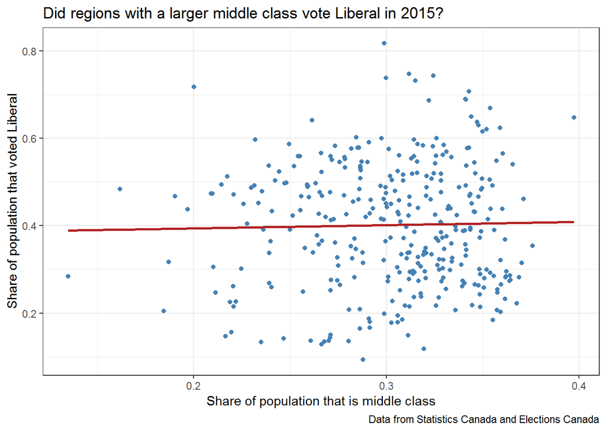

```r
ggplot(dat,
       aes(x=share_middle_class,
           y=Liberal)) +
  geom_point(colour="steelblue") +
  geom_smooth(method="lm", se=F, colour="firebrick") +
  theme_bw() +
  labs(title="Did regions with a larger middle class vote Liberal in 2015?",
       x="Share of population that is middle class",
       y="Share of population that voted Liberal",
       caption="Data from Statistics Canada and Elections Canada")
```

There doesn’t seem to be a strong relationship between the Liberal vote share and the share of the population that is middle class. Let’s quantify it with a regression:

```r
m1 <- lm(Liberal ~ share_middle_class, data = dat)
library(huxtable)
huxreg(m1)
```

|  | (1) |
| --- | --- |
| (Intercept) | 0.379 *** |
|  | (0.054) |
| share_middle_class | 0.074 |
|  | (0.178) |
| N | 338 |
| R2 | 0.001 |
| logLik | 184.041 |
| AIC | -362.082 |
| *** p < 0.001; ** p < 0.01; * p < 0.05. |  |

What do these statistics mean? How do they compare to the plot above? The regression is a mathematical representation of the red line in the plot above. The intercept is where the red line hits the y-axis, and the coefficient describes how the y variable changes with a one-unit change in the x variable. There was not much of a relationship evident in the graph, and this is echoed in the regression results – a non-significant and small coefficient on the `share_middle_class` variable.

One concern we may have in interpreting this regression relates to confounding variables. That is, there may be a relationship between the share of middle class voters and the Liberal vote outcome, but it is being hidden because there are other differences in the populations that are both correlated with the middle class share as well as the Liberal vote share. We can try to use multiple regression to see if this is what’s happening. For example, education is one such variable (why?). We can include some variables that measure educational outcomes in our regression, to see if these influence the coefficient that we’re interested in.

```r
m2 <- lm(Liberal ~ share_middle_class + share_low_educ + share_uni_educ, data=dat)
huxreg(m2)
```

|  | (1) |
| --- | --- |
| (Intercept) | -0.222 * |
|  | (0.089) |
| share_middle_class | 0.682 *** |
|  | (0.174) |
| share_low_educ | 0.802 *** |
|  | (0.161) |
| share_uni_educ | 1.189 *** |
|  | (0.133) |
| N | 338 |
| R2 | 0.202 |
| logLik | 222.055 |
| AIC | -434.110 |
| *** p < 0.001; ** p < 0.01; * p < 0.05. |  |

These results are quite different than the results we had before. What do they imply? How do we interpret them? Let’s try another regression, with even more explanatory variables.

```r
m4 <- lm(Liberal ~ share_middle_class + share_low_educ + share_uni_educ + share_imm + share_english + share_french + share_married + share_divorced + share_young + share_old, data=dat)
huxreg(m4)
```

|  | (1) |
| --- | --- |
| (Intercept) | 0.041 |
|  | (0.241) |
| share_middle_class | 0.931 *** |
|  | (0.258) |
| share_low_educ | 0.455 |
|  | (0.273) |
| share_uni_educ | 0.684 ** |
|  | (0.248) |
| share_imm | -0.044 |
|  | (0.080) |
| share_english | -0.273 *** |
|  | (0.047) |
| share_french | -0.273 ** |
|  | (0.094) |
| share_married | 1.344 ** |
|  | (0.459) |
| share_divorced | -4.124 *** |
|  | (0.812) |
| share_young | -1.577 *** |
|  | (0.375) |
| share_old | -0.269 |
|  | (0.296) |
| N | 337 |
| R2 | 0.367 |
| logLik | 259.952 |
| AIC | -495.904 |
| *** p < 0.001; ** p < 0.01; * p < 0.05. |  |

How do you interpret these results? Did we answer the research question? What else would you like to see?